# lab1

Yuxin He

2023-10-27

## Question 1

Discuss the advantages and challenges associated with an open data science approach. Provide an example based on this week’s reading. (1-2 paragraphs)

Open data science approach is an aspect of broader open science movement that can make scientific data and methods openly accessible. It contains sharing data sets, code and other research materials that allows others to access and use.

This has advantages and disadvantages. For example, it allows for greater transparency and reproducibility in research. People from different areas and organizations can share data and code to solve problems faster. And it promotes reproducibility in research. Reducing the probability of bias or errors. Besides, it also foster innovation and creativity. People can develop new methods and create easier.

However, there are some challenges. Sharing data can cause some security risks. We need to develop proper data security to protect the open data. We will face some privacy and ethical concerns due to the open data. Furthermore, open datasets won’t always have high quality resource, there may be problems with missing data.

## Question2

Create a markdown document that showcases an analysis of this week’s data or any other dataset of your choice. Include descriptive text that explains your analysis, and incorporate figures and geovisualizations.Include 1 chart and 1 map. Structure and explain your analysis with text, headings, highlights, images and other markdown basics.

## My analysis

I used ‘Gradient colour scales’ in ggplot2 to make my geovisualization. I made one map about the land use of Whashtenaw County.

```r
library(ggplot2)
library(sf)
library(ggspatial)
library(viridis)
## the function gives the hexadecimal colors
## the interger give the numbers of colors
magma(10)
```

```
##  [1] "#000004FF" "#180F3EFF" "#451077FF" "#721F81FF" "#9F2F7FFF" "#CD4071FF"
##  [7] "#F1605DFF" "#FD9567FF" "#FEC98DFF" "#FCFDBFFF"
```

I used the color palette Viridis that are interpretable for visually impaired to create this map.

```r
boulder <- st_read("land_utm.shp")
boulder
```

```
## Simple feature collection with 12301 features and 6 fields
## Geometry type: POLYGON
## Dimension:     XY
## Bounding box:  xmin: 240895.7 ymin: 4662331 xmax: 290209.2 ymax: 4701671
## Projected CRS: NAD83 / UTM zone 17N
## First 10 features:
##          AREA  PERIMETER LAND_UTM_ LAND_UTM_I LEVEL5         LAND_USE
## 1  7270324.49 62013.6057         2          2  21000     Agricultural
## 2   245651.76  5046.1328         3          1  41200 Deciduous Forest
## 3   216087.73  4452.3526         4          3  61200          Wetland
## 4    68711.70  1197.4296         5          4  41200 Deciduous Forest
## 5   152123.06  1908.5035         6          8  31000       Open Field
## 6   217810.26  3532.2636         7          7  41200 Deciduous Forest
## 7    79454.37  2306.8027         8          6  61200          Wetland
## 8    13169.50   495.6605         9         10  32000       Open Field
## 9    24272.51   667.2111        10          5  62200          Wetland
## 10  101286.67  1303.9083        11          9  31000       Open Field
##                          geometry
## 1  POLYGON ((244926.2 4696720,...
## 2  POLYGON ((243139.2 4701642,...
## 3  POLYGON ((243420.6 4701629,...
## 4  POLYGON ((243640.2 4701619,...
## 5  POLYGON ((243947.2 4701603,...
## 6  POLYGON ((244406.4 4701586,...
## 7  POLYGON ((244585.2 4701580,...
## 8  POLYGON ((244405.4 4701434,...
## 9  POLYGON ((244784.8 4701572,...
## 10 POLYGON ((245083.7 4701555,...
```

```r
boulder <- st_read("land_utm.shp")## Read the shape file land_utm.shp
```

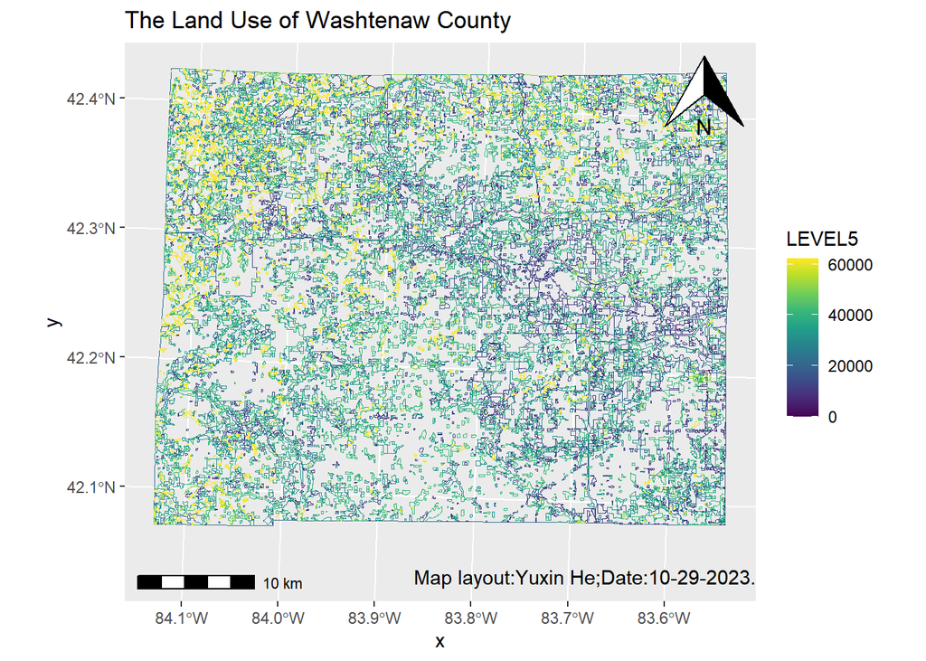

```r
ggplot() +
  ggtitle("The Land Use of Washtenaw County") + ##Give the map a title
    geom_sf(data = boulder, aes(color=LEVEL5),
    fill =NA, alpha = .2) + ## Draw a map by using the LEVEL5 field
    scale_colour_gradientn(colours = viridis(10))+ ## Define the scale color
   annotation_north_arrow(location = "right")+ ## Add north arrow to map
  annotation_scale()+ ## Add a map scale to map
  annotate("text",x = 278000, y = 4658000,
  label = "Map layout:Yuxin He;Date:10-29-2023.")##Add the date and author to map
```

I used the data of AREA and LAND_USE from land_utm.shp to create the bar chart .

```r
boulder <- st_read("land_utm.shp")## read the shape file
boulder
```

```
## Simple feature collection with 12301 features and 6 fields
## Geometry type: POLYGON
## Dimension:     XY
## Bounding box:  xmin: 240895.7 ymin: 4662331 xmax: 290209.2 ymax: 4701671
## Projected CRS: NAD83 / UTM zone 17N
## First 10 features:
##          AREA  PERIMETER LAND_UTM_ LAND_UTM_I LEVEL5         LAND_USE
## 1  7270324.49 62013.6057         2          2  21000     Agricultural
## 2   245651.76  5046.1328         3          1  41200 Deciduous Forest
## 3   216087.73  4452.3526         4          3  61200          Wetland
## 4    68711.70  1197.4296         5          4  41200 Deciduous Forest
## 5   152123.06  1908.5035         6          8  31000       Open Field
## 6   217810.26  3532.2636         7          7  41200 Deciduous Forest
## 7    79454.37  2306.8027         8          6  61200          Wetland
## 8    13169.50   495.6605         9         10  32000       Open Field
## 9    24272.51   667.2111        10          5  62200          Wetland
## 10  101286.67  1303.9083        11          9  31000       Open Field
##                          geometry
## 1  POLYGON ((244926.2 4696720,...
## 2  POLYGON ((243139.2 4701642,...
## 3  POLYGON ((243420.6 4701629,...
## 4  POLYGON ((243640.2 4701619,...
## 5  POLYGON ((243947.2 4701603,...
## 6  POLYGON ((244406.4 4701586,...
## 7  POLYGON ((244585.2 4701580,...
## 8  POLYGON ((244405.4 4701434,...
## 9  POLYGON ((244784.8 4701572,...
## 10 POLYGON ((245083.7 4701555,...
```

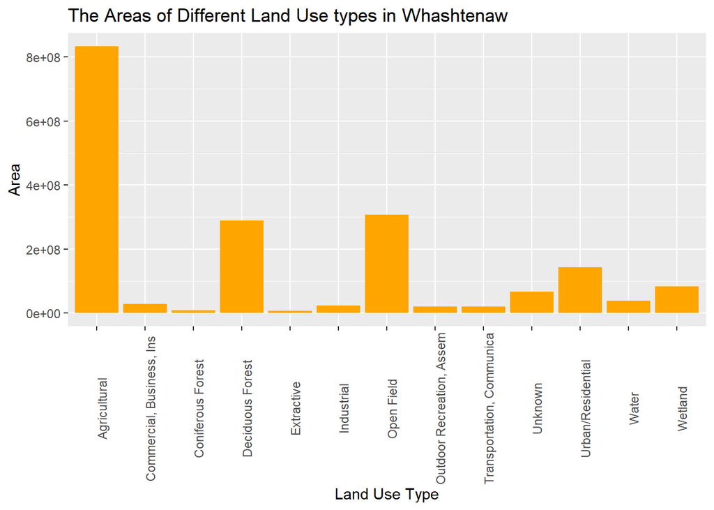

```r
##plot bar chart about areas in Whashtenaw
boulder %>%
  ggplot(aes(x=LAND_USE, y= AREA)) + ##set X and Y values
  geom_bar(stat='identity',fill='orange')+ ##set stat to show original count and fill color
  labs(title="The Areas of Different Land Use types in Whashtenaw",x='Land Use Type', y='Area')+ ##set title and X,Y axes labels
  theme(axis.text.x=element_text(angle=90)) ##set the rotation of X text to 90 degrees
```

## Bonus:

Capture a screenshot of the history of your Git commits. Share your strategy for utilizing Git in your workflow

After installing Git and setting up a Git Repository, I created a “.gitignore” file and connected R studio to Git. Then I can manage branches and change the project in R studio. I can pull changes from the remote and push changes back to the remote.